# Final Exercise MSiA Bootcamp 2020

Louis-Charles Genereux

15/09/2020

# Task 1: Import the data

The ‘schools’ dataframe contains data on schools within New York State. SOURCE: New York State Department of Education The ‘demographics’ dataframe contains census data on counties in which schools are situated. SOURCE: US Census Bureau

```r
schools <- read_csv(here::here("data/nys_schools.csv"))
```

```r
demographics <- read_csv(here::here("data/nys_acs.csv"))
```

# Task 2: Exploring the data

### Exploring the ‘schools’ dataframe

Summary of schools dataframe

```r
summary(schools)
```

```
##   school_cd         school_name        district_name      county_name
##  Length:35663       Length:35663       Length:35663       Length:35663
##  Class :character   Class :character   Class :character   Class :character
##  Mode  :character   Mode  :character   Mode  :character   Mode  :character
##
##
##
##     region               year       total_enroll    per_free_lunch
##  Length:35663       Min.   :2008   Min.   : -99.0   Min.   :-99.0000
##  Class :character   1st Qu.:2010   1st Qu.: 339.0   1st Qu.:  0.1900
##  Mode  :character   Median :2013   Median : 469.0   Median :  0.4200
##                     Mean   :2013   Mean   : 523.6   Mean   :  0.4188
##                     3rd Qu.:2015   3rd Qu.: 648.0   3rd Qu.:  0.7200
##                     Max.   :2017   Max.   :2347.0   Max.   :257.0000
##  per_reduced_lunch      per_lep          mean_ela_score  mean_math_score
##  Min.   :-99.00000   Min.   :-99.00000   Min.   :-99.0   Min.   :-99.0
##  1st Qu.:  0.03000   1st Qu.:  0.00000   1st Qu.:296.0   1st Qu.:298.0
##  Median :  0.06000   Median :  0.03000   Median :324.2   Median :330.8
##  Mean   :  0.02852   Mean   :  0.04124   Mean   :447.1   Mean   :456.0
##  3rd Qu.:  0.10000   3rd Qu.:  0.11000   3rd Qu.:666.3   3rd Qu.:683.5
##  Max.   : 53.00000   Max.   :  1.00000   Max.   :720.8   Max.   :738.7
```

Investigating NA or erroneous values - counting the number of rows per column

```r
#determining the number of rows in the schools data frame
nrow(schools)
```

```
## [1] 35663
```

```r
#writing a function to count the numbers of rows that are NAs per column
na_row_counter <- function(df) {
  # for each column, this code will return the number of rows that satisfy the conditions
  # the which function returns the position within the column which matches the condition (in vector form)
  # the length function returns the number of rows that match the condition
 length(which(df == -99 | df == -99.0000 | df == "-99" | df == "-99.0" | df == "-99.0000" | is.na(df)))
}

# apply the na_row_counter function for  every column of the dataframe and return a df with count of NAs/ -99
data.frame(sapply(schools, na_row_counter))
```

```
##                   sapply.schools..na_row_counter.
## school_cd                                       0
## school_name                                     0
## district_name                                1725
## county_name                                    19
## region                                         19
## year                                            0
## total_enroll                                   13
## per_free_lunch                                 15
## per_reduced_lunch                              15
## per_lep                                        13
## mean_ela_score                               2208
## mean_math_score                              2210
```

### Exploring the ‘demographics’ dataframe

Summary of demographics dataframe

```r
summary(demographics)
```

```
##  county_name             year      county_per_poverty median_household_income
##  Length:496         Min.   :2009   Min.   :0.04689    Min.   : 33794
##  Class :character   1st Qu.:2011   1st Qu.:0.10903    1st Qu.: 46347
##  Mode  :character   Median :2012   Median :0.12884    Median : 50134
##                     Mean   :2012   Mean   :0.13085    Mean   : 54116
##                     3rd Qu.:2014   3rd Qu.:0.14929    3rd Qu.: 56448
##                     Max.   :2016   Max.   :0.29935    Max.   :102044
##  county_per_bach
##  Min.   :0.07574
##  1st Qu.:0.11018
##  Median :0.13169
##  Mean   :0.14410
##  3rd Qu.:0.17431
##  Max.   :0.31795
```

Investigating NA or erroneous values - counting the number of rows per column

```r
#determining the number of rows in the schools data frame
nrow(demographics)
```

```
## [1] 496
```

```r
# apply the na_row_counter function for  every column of the dataframe and return a df with count of NAs/ -99
data.frame(sapply(demographics, na_row_counter))
```

```
##                         sapply.demographics..na_row_counter.
## county_name                                                0
## year                                                       0
## county_per_poverty                                         0
## median_household_income                                    0
## county_per_bach                                            0
```

# Task 3: Recoding and variable manipulation

## 3.1 Deal with missing values in the ‘Schools’ dataframe

I will remove the NA or empty values, as I do not want erroneous data to affect my analyses

```r
# function to finding values within a vector (row within a dataframe)
row_to_be_deleted <- function(df) {
  if(any(df %in% c(NA, -99, "-99", "-99.0", "-99.0000" ))) {
    # retun 1 if row should be removed
    1
  } else {
    # return 0 if row should be kept
    0
  }
}

# Apply function to rows, resulting in new column called "rows_to_be_removed"
schools$rows_to_be_removed <- apply(schools, 1, row_to_be_deleted)

# Remove rows containing empty values (keep only rows where rows_to_be_removed = 0)
schools_clean <- schools[schools$rows_to_be_removed==0, ]

# removing column which we used to identify NA rows
schools_clean <- schools_clean[,-c(13)]

# final adjustment - adding absolute "total free lunch" and "total reduced lunch"
schools_clean$total_free_lunch <- schools_clean$total_enroll * schools_clean$per_free_lunch
schools_clean$total_red_lunch <- schools_clean$total_enroll * schools_clean$per_reduced_lunch
```

## 3.2 Classifying counties based on their levels of poverty

I will classify counties as “high”, “medium”, and “low” poverty for each year, given that I have data across various years and that some counties have changed their relative position over time

```r
### Compute the cutoffs for low, medium and high poverty levels for each year

# Create dataframe to keep results
yearly_poverty_cutoffs <- data.frame("year" = NA, "tier_one" = NA, "tier_two" = NA)

# Set up loop to fill data frame
n_years_demographics <- max(demographics$year) - min(demographics$year) + 1
for (i in 1:n_years_demographics) {
  current_year <- min(demographics$year) + i - 1
  yearly_poverty_cutoffs[i,1] <-current_year
  yearly_poverty_cutoffs[i,2] <- quantile(demographics$county_per_poverty[demographics$year==current_year], c(.33))
  yearly_poverty_cutoffs[i,3] <- quantile(demographics$county_per_poverty[demographics$year==current_year], c(.66))
}

### Classify counties as low, medium or high poverty based on the year by year quantiles calculated

# create new column
demographics$poverty_classification <- NA

n_row_demographic_data <- nrow(demographics)
for (i in 1:n_row_demographic_data) {
    year_index <- as.double(demographics[i, "year"])
    county_poverty <- as.double(demographics[i, "county_per_poverty"])
    low_cutoff <- yearly_poverty_cutoffs$tier_one[yearly_poverty_cutoffs$year==year_index]
    high_cutoff <- yearly_poverty_cutoffs$tier_two[yearly_poverty_cutoffs$year==year_index]

    if (county_poverty < low_cutoff) {
      demographics$poverty_classification[i] <- "low relative poverty"
    } else if (county_poverty < high_cutoff) {
      demographics$poverty_classification[i] <- "medium relative poverty"
    } else {
      demographics$poverty_classification[i] <- "high relative poverty"
    }
}

head(demographics[,c(1,2,3,4,6)], 10)
```

```
## # A tibble: 10 x 5
##    county_name  year county_per_poverty median_household_in… poverty_classifica…
##    <chr>       <dbl>              <dbl>                <dbl> <chr>
##  1 ALBANY       2009              0.118                55350 medium relative po…
##  2 ALBANY       2010              0.119                56090 medium relative po…
##  3 ALBANY       2011              0.121                57715 medium relative po…
##  4 ALBANY       2012              0.124                59359 medium relative po…
##  5 ALBANY       2013              0.123                59394 medium relative po…
##  6 ALBANY       2014              0.129                59940 medium relative po…
##  7 ALBANY       2015              0.128                59887 medium relative po…
##  8 ALBANY       2016              0.123                60904 low relative pover…
##  9 ALLEGANY     2009              0.152                40917 high relative pove…
## 10 ALLEGANY     2010              0.149                41305 high relative pove…
```

## 3.3 Scale test scores

I will create a z-score for the math and ELA tests so that a school’s performance can be compared year on year relative to peers

```r
schools_clean %>%
  group_by(year) %>%
  mutate(scaled_math_score = scale(mean_math_score, center = TRUE, scale = TRUE)) %>%
  mutate(scaled_ela_score = scale(mean_ela_score, center = TRUE, scale = TRUE))
```

```
## # A tibble: 31,937 x 16
## # Groups:   year [10]
##    school_cd school_name district_name county_name region  year total_enroll
##    <chr>     <chr>       <chr>         <chr>       <chr>  <dbl>        <dbl>
##  1 01010001… MONTESSORI… ALBANY CITY … ALBANY      CAPIT…  2008          316
##  2 01010001… MONTESSORI… ALBANY CITY … ALBANY      CAPIT…  2009          312
##  3 01010001… MONTESSORI… ALBANY CITY … ALBANY      CAPIT…  2010          300
##  4 01010001… MONTESSORI… ALBANY CITY … ALBANY      CAPIT…  2011          326
##  5 01010001… MONTESSORI… ALBANY CITY … ALBANY      CAPIT…  2012          294
##  6 01010001… MONTESSORI… ALBANY CITY … ALBANY      CAPIT…  2013          321
##  7 01010001… MONTESSORI… ALBANY CITY … ALBANY      CAPIT…  2014          335
##  8 01010001… MONTESSORI… ALBANY CITY … ALBANY      CAPIT…  2015          347
##  9 01010001… MONTESSORI… ALBANY CITY … ALBANY      CAPIT…  2016          366
## 10 01010001… MONTESSORI… ALBANY CITY … ALBANY      CAPIT…  2017          359
## # … with 31,927 more rows, and 9 more variables: per_free_lunch <dbl>,
## #   per_reduced_lunch <dbl>, per_lep <dbl>, mean_ela_score <dbl>,
## #   mean_math_score <dbl>, total_free_lunch <dbl>, total_red_lunch <dbl>,
## #   scaled_math_score[,1] <dbl>, scaled_ela_score[,1] <dbl>
```

https://www.r-bloggers.com/r-tutorial-series-centering-variables-and-generating-z-scores-with-the-scale-function/

# Task 4: Merging data frames

Inner join, so that only observations that match in both dataframes are retained

```r
schools_and_demographics <- inner_join(schools_clean, demographics, by= c("year" = "year", "county_name" = "county_name"))
str(schools_and_demographics)
```

```
## tibble [25,586 × 18] (S3: tbl_df/tbl/data.frame)
##  $ school_cd              : chr [1:25586] "010100010014" "010100010014" "010100010014" "010100010014" ...
##  $ school_name            : chr [1:25586] "MONTESSORI MAGNET SCHOOL" "MONTESSORI MAGNET SCHOOL" "MONTESSORI MAGNET SCHOOL" "MONTESSORI MAGNET SCHOOL" ...
##  $ district_name          : chr [1:25586] "ALBANY CITY SCHOOL DISTRICT" "ALBANY CITY SCHOOL DISTRICT" "ALBANY CITY SCHOOL DISTRICT" "ALBANY CITY SCHOOL DISTRICT" ...
##  $ county_name            : chr [1:25586] "ALBANY" "ALBANY" "ALBANY" "ALBANY" ...
##  $ region                 : chr [1:25586] "CAPITAL DISTRICT" "CAPITAL DISTRICT" "CAPITAL DISTRICT" "CAPITAL DISTRICT" ...
##  $ year                   : num [1:25586] 2009 2010 2011 2012 2013 ...
##  $ total_enroll           : num [1:25586] 312 300 326 294 321 335 347 366 327 366 ...
##  $ per_free_lunch         : num [1:25586] 0.32 0.26 0.22 0.31 0.25 0.35 0.22 0.29 0.69 0.53 ...
##  $ per_reduced_lunch      : num [1:25586] 0.08 0.08 0.07 0.06 0.08 0.04 0 0.02 0.11 0.01 ...
##  $ per_lep                : num [1:25586] 0.02 0.03 0.03 0.03 0.03 0.06 0.06 0.05 0.05 0.09 ...
##  $ mean_ela_score         : num [1:25586] 673 670 667 670 310 ...
##  $ mean_math_score        : num [1:25586] 679 683 681 687 311 ...
##  $ total_free_lunch       : num [1:25586] 99.8 78 71.7 91.1 80.2 ...
##  $ total_red_lunch        : num [1:25586] 25 24 22.8 17.6 25.7 ...
##  $ county_per_poverty     : num [1:25586] 0.118 0.119 0.121 0.124 0.123 ...
##  $ median_household_income: num [1:25586] 55350 56090 57715 59359 59394 ...
##  $ county_per_bach        : num [1:25586] 0.19 0.197 0.199 0.198 0.205 ...
##  $ poverty_classification : chr [1:25586] "medium relative poverty" "medium relative poverty" "medium relative poverty" "medium relative poverty" ...
```

# Task 5: Create summary tables

### Table 1: Total enrollment, percent of students qualifying for free or reduced price lunch, and percent of population in poverty, for each county in 2016

```r
table_1 <-
  schools_and_demographics  %>%
  filter(year == 2016) %>%
  group_by(county_name) %>%
  summarise(enrollment = sum(total_enroll),
            per_f_lunch = (sum(total_free_lunch)/sum(enrollment)),
            per_red_lunch =(sum(total_red_lunch)/sum(enrollment)),
            per_poverty = mean(county_per_poverty))
head(table_1[order(table_1$enrollment, decreasing = TRUE),])
```

```
## # A tibble: 6 x 5
##   county_name enrollment per_f_lunch per_red_lunch per_poverty
##   <chr>            <dbl>       <dbl>         <dbl>       <dbl>
## 1 KINGS           210368       0.671        0.0458      0.225
## 2 QUEENS          208933       0.611        0.0751      0.145
## 3 BRONX           155510       0.811        0.0362      0.298
## 4 SUFFOLK         142447       0.337        0.0457      0.0711
## 5 NASSAU          123610       0.244        0.0342      0.0592
## 6 WESTCHESTER      98273       0.350        0.0426      0.0955
```

```r
summary(table_1)
```

```
##  county_name          enrollment      per_f_lunch     per_red_lunch
##  Length:62          Min.   :   407   Min.   :0.1690   Min.   :0.02683
##  Class :character   1st Qu.:  4641   1st Qu.:0.3854   1st Qu.:0.04286
##  Mode  :character   Median :  8138   Median :0.4430   Median :0.05862
##                     Mean   : 27838   Mean   :0.4386   Mean   :0.05964
##                     3rd Qu.: 22148   3rd Qu.:0.4861   3rd Qu.:0.07354
##                     Max.   :210368   Max.   :0.8110   Max.   :0.10918
##   per_poverty
##  Min.   :0.05091
##  1st Qu.:0.11673
##  Median :0.13621
##  Mean   :0.13630
##  3rd Qu.:0.15122
##  Max.   :0.29769
```

### Table 2: Percent of population in poverty, percent of students qualifying for free or reduced price lunch, mean reading score, and mean math score, for the counties with the top 5 and bottom 5 poverty rate in 2016

```r
# table for 5 poorest counties (highest poverty rate)
table_2a <-
  schools_and_demographics  %>%
  filter(year == 2016) %>%
  group_by(county_name) %>%
  summarise(percent_in_poverty = mean(county_per_poverty),
            enrollment = sum(total_enroll),
            per_f_lunch = (sum(total_free_lunch)/sum(enrollment)),
            per_lunch =(sum(total_red_lunch)/sum(enrollment)),
            mean_reading= mean(mean_ela_score),
            mean_math = mean(mean_math_score)) %>%
  top_n(5, percent_in_poverty)
# table for 5 richest counties (lowest poverty rate)
table_2b <-
  schools_and_demographics  %>%
  filter(year == 2016) %>%
  group_by(county_name) %>%
  summarise(percent_in_poverty = mean(county_per_poverty),
            enrollment = sum(total_enroll),
            per_f_lunch = (sum(total_free_lunch)/sum(enrollment)),
            per_lunch =(sum(total_red_lunch)/sum(enrollment)),
            mean_reading= mean(mean_ela_score),
            mean_math = mean(mean_math_score)) %>%
  top_n(-5, percent_in_poverty)
# merging the top 5 to the bottom 5
table_2 <- rbind(table_2a, table_2b)

# creating the desired output
head(table_2[order(table_2$percent_in_poverty, decreasing = TRUE),],10)
```

```
## # A tibble: 10 x 7
##    county_name percent_in_pove… enrollment per_f_lunch per_lunch mean_reading
##    <chr>                  <dbl>      <dbl>       <dbl>     <dbl>        <dbl>
##  1 BRONX                 0.298      155510       0.811    0.0362         293.
##  2 KINGS                 0.225      210368       0.671    0.0458         303.
##  3 MONTGOMERY            0.202        4903       0.543    0.0284         290.
##  4 CHAUTAUQUA            0.185       13102       0.533    0.0400         297.
##  5 OSWEGO                0.175       12724       0.503    0.0666         294.
##  6 DUTCHESS              0.0864      22247       0.281    0.0467         303.
##  7 SUFFOLK               0.0711     142447       0.337    0.0457         307.
##  8 SARATOGA              0.0631      21850       0.210    0.0304         312.
##  9 NASSAU                0.0592     123610       0.244    0.0342         317.
## 10 PUTNAM                0.0509       8799       0.169    0.0292         312.
## # … with 1 more variable: mean_math <dbl>
```

```r
summary(table_2)
```

```
##  county_name        percent_in_poverty   enrollment      per_f_lunch
##  Length:10          Min.   :0.05091    Min.   :  4903   Min.   :0.1690
##  Class :character   1st Qu.:0.06510    1st Qu.: 12818   1st Qu.:0.2531
##  Mode  :character   Median :0.13074    Median : 22048   Median :0.4197
##                     Mean   :0.14157    Mean   : 71556   Mean   :0.4302
##                     3rd Qu.:0.19754    3rd Qu.:137738   3rd Qu.:0.5409
##                     Max.   :0.29769    Max.   :210368   Max.   :0.8110
##    per_lunch        mean_reading     mean_math
##  Min.   :0.02844   Min.   :289.5   Min.   :287.2
##  1st Qu.:0.03133   1st Qu.:295.2   1st Qu.:298.9
##  Median :0.03807   Median :302.7   Median :302.1
##  Mean   :0.04031   Mean   :302.8   Mean   :304.3
##  3rd Qu.:0.04578   3rd Qu.:310.6   3rd Qu.:311.9
##  Max.   :0.06659   Max.   :316.9   Max.   :320.3
```

# 6: Data visualization

6.1 The relationship between access to free/reduced price lunch and test performance, at the *school* level.

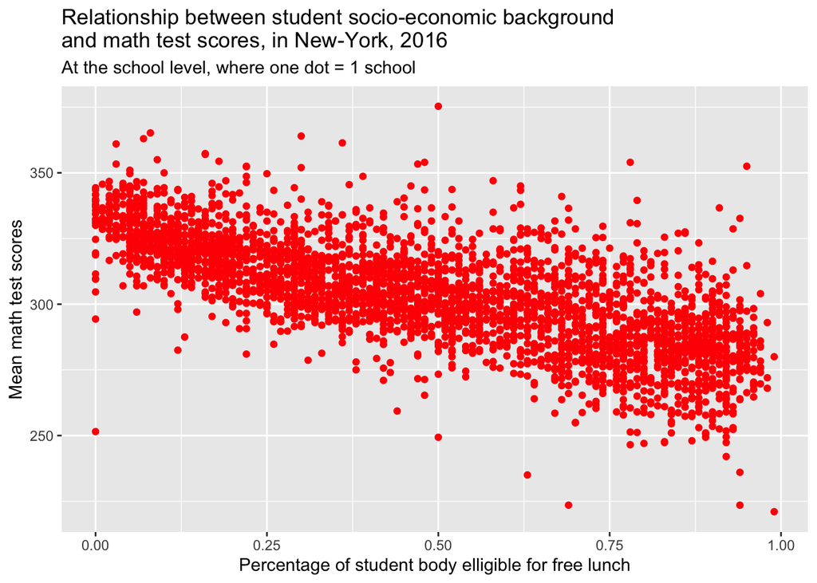

```r
schools_and_demographics %>%
  filter(year == 2016) %>%
  group_by(school_name) %>%
  ggplot() + geom_point(aes(x= per_free_lunch, y = mean_math_score), col="red") +
  labs(title = "Relationship between student socio-economic background \nand math test scores, in New-York, 2016",
       subtitle = "At the school level, where one dot = 1 school",
       x= "Percentage of student body elligible for free lunch", y="Mean math test scores")
```

6.2 Average test performance across *counties* with high, low, and medium poverty.

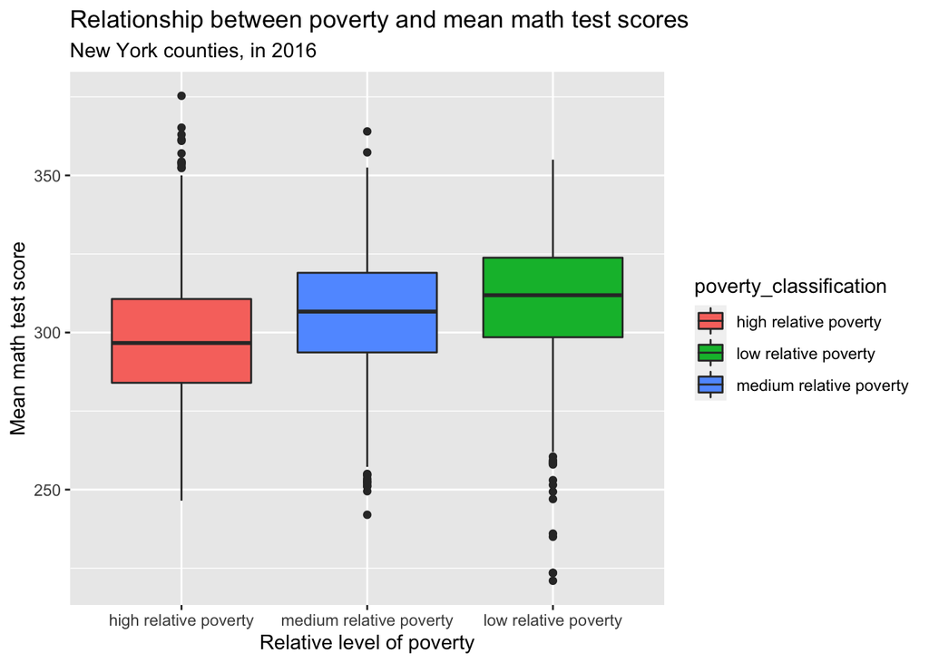

```r
schools_and_demographics %>%
  filter(year == 2016) %>%
  group_by(poverty_classification) %>%
  ggplot( aes(x= reorder(poverty_classification, mean_math_score, FUN = median), y = mean_math_score, fill = poverty_classification)) +
 geom_boxplot() +
  labs(title="Relationship between poverty and mean math test scores",
  subtitle="New York counties, in 2016")+
  theme(legend.position="right") +
  xlab("Relative level of poverty")+
  ylab("Mean math test score")
```

# 7: Answering questions

**What can the data tell us about the relationship between poverty and test performance in New York public schools? Has this relationship changed over time? Is this relationship at all moderated by access to free/reduced price lunch?**

A quick visualization reveals that schools within poorer counties have continuously yielded lower math test scores than schools within richer counties between 2009 and 2016.

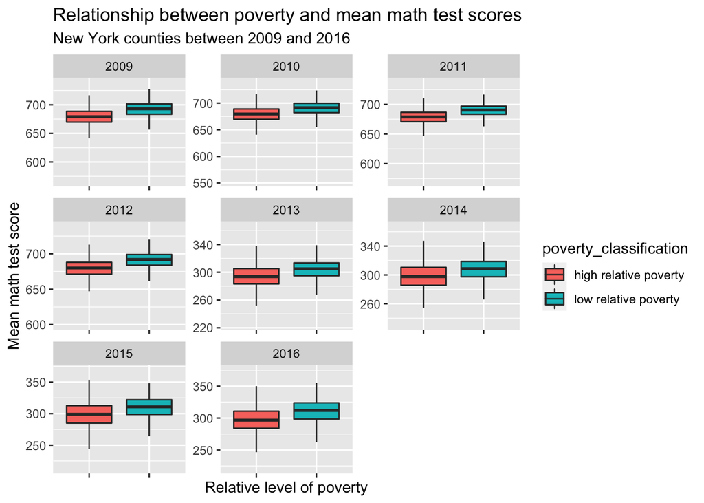

```r
schools_and_demographics %>%
  group_by(poverty_classification) %>%
  filter(poverty_classification == "low relative poverty" | poverty_classification == "high relative poverty" ) %>%
  ggplot( aes(x= reorder(poverty_classification, mean_math_score, na.rm = TRUE), y = mean_math_score, fill = poverty_classification)) +
 geom_boxplot(outlier.shape=NA) +
  labs(title="Relationship between poverty and mean math test scores",
  subtitle="New York counties between 2009 and 2016")+
  facet_wrap(~year, scales = "free") +
  theme(legend.position="right", axis.text.x = element_blank()) +
  xlab("Relative level of poverty")+
  ylab("Mean math test score")
```

We can see below that there is a strong positive correlation between county poverty levels and access to free lunches, meaning that schools in poor counties tend to have high levels of students qualifying for free lunches.

However, based on this high correlation, it might be misleading to use both county poverty rate and access to free lunch as two predictors of math scores

```r
### Evaluating the correlation between district poverty and percentage of students qualifying for free lunch

# Create dataframe to keep results
relationship_between_county_poverty_and_free_lunch <- data.frame("year" = NA, "correlation" = NA)

years_observed <- unique(schools_and_demographics$year)
row_counter <- 1
for (i in years_observed) {
  year_index <- i
  county_poverty_for_year <- schools_and_demographics$county_per_poverty[schools_and_demographics$year==year_index]
  free_lunch_for_year <- schools_and_demographics$per_free_lunch[schools_and_demographics$year==year_index]
  correlation <- cor(county_poverty_for_year, free_lunch_for_year )
  relationship_between_county_poverty_and_free_lunch[row_counter,1] <- year_index
  relationship_between_county_poverty_and_free_lunch[row_counter,2] <- correlation
  row_counter <- row_counter +1
}
relationship_between_county_poverty_and_free_lunch[1:8,]
```

```
##   year correlation
## 1 2009   0.6559851
## 2 2010   0.6552637
## 3 2011   0.6546976
## 4 2012   0.6318273
## 5 2013   0.6175914
## 6 2014   0.6439118
## 7 2015   0.1121363
## 8 2016   0.5891973
```

Using univariate models to predict test scores (given that we cannot use both county poverty and access to free lunch in the same model - due to high collinearity), we see that poverty can explain significant variation in test scores

Over 8 years, the proportion of a school’s students accessing free lunches has explained ~45% of variation in test scores (affecting test scores downward). This is 30% more variation explained than by looking at county poverty only (which itself only explains ~15% of stest score variation)

```r
### Evaluating the relationship between district poverty, percentage of students qualifying for free lunch and test scores

# Create dataframe to keep results
regression_results_univariate <- data.frame("year" = NA, "Coefficient for poverty" = NA,
                                            "poverty model significance (R2)" = NA,
                                            "Coefficient for free lunch"= NA,
                                            "free lunch model significance (R2)" = NA,
                                            "strongest predictor")

years_observed <- unique(schools_and_demographics$year)
row_counter <- 1
for (i in years_observed) {
  year_index <- i

  yearly_data <- schools_and_demographics[schools_and_demographics$year==year_index,]
  model_poverty <-lm(mean_ela_score ~ county_per_poverty  , data = yearly_data)
  model_lunch <-lm(mean_ela_score ~  per_free_lunch , data = yearly_data)


  regression_results_univariate[row_counter,1] <- year_index
  regression_results_univariate[row_counter,2] <- summary(model_poverty)$coefficients[2]
  regression_results_univariate[row_counter,3] <- summary(model_poverty)$r.squared
  regression_results_univariate[row_counter,4] <- summary(model_lunch)$coefficients[2]
  regression_results_univariate[row_counter,5] <- summary(model_lunch)$r.squared
  regression_results_univariate[row_counter,6] <- ifelse(summary(model_poverty)$r.squared >= summary(model_lunch)$r.squared, "poverty",
                                              "lunch")

  row_counter <- row_counter +1
}
regression_results_univariate[1:8,]
```

```
##   year Coefficient.for.poverty poverty.model.significance..R2.
## 1 2009              -105.94226                      0.23028797
## 2 2010               -91.37005                      0.21295533
## 3 2011               -67.17052                      0.16728776
## 4 2012               -68.85171                      0.17706546
## 5 2013               -90.14661                      0.13548393
## 6 2014               -72.36140                      0.09012183
## 7 2015               -71.17525                      0.07498444
## 8 2016               -64.93341                      0.06560961
##   Coefficient.for.free.lunch free.lunch.model.significance..R2.
## 1                -32.7626556                        0.542955228
## 2                -29.3122846                        0.526946885
## 3                -23.3585598                        0.490007694
## 4                -24.6150910                        0.512572330
## 5                -38.0302162                        0.539980003
## 6                -36.5123330                        0.476771180
## 7                 -0.5931089                        0.003946224
## 8                -39.9942637                        0.459637268
##   X.strongest.predictor.
## 1                  lunch
## 2                  lunch
## 3                  lunch
## 4                  lunch
## 5                  lunch
## 6                  lunch
## 7                poverty
## 8                  lunch
```

```r
### Comparing both approaches

# Mean variation in test scores explained by free lunch
mean(regression_results_univariate$free.lunch.model.significance..R2.)
```

```
## [1] 0.4441021
```

```r
# Incremental variation in test scores explained through free lunch model vs county poverty model
mean(regression_results_univariate$free.lunch.model.significance..R2.) - mean(regression_results_univariate$poverty.model.significance..R2.)
```

```
## [1] 0.2998776
```

To be ignored (given high collinearity between poverty and access to free lunch)

```r
### Evaluating the relationship between district poverty, percentage of students qualifying for free lunch and test scores

# Create dataframe to keep results
regression_results <- data.frame("year" = NA, "Coefficient for poverty" = NA,  "P-value for poverty" = NA,
                                 "Coefficient for free lunch"= NA,  "P-value for free lunch" = NA,
                                 "Model significance (R2)")

years_observed <- unique(schools_and_demographics$year)
row_counter <- 1
for (i in years_observed) {
  year_index <- i

  yearly_data <- schools_and_demographics[schools_and_demographics$year==year_index,]
  model <-lm(mean_ela_score ~ county_per_poverty + per_free_lunch , data = yearly_data)

  regression_results[row_counter,1] <- year_index
  regression_results[row_counter,2] <- summary(model)$coefficients[2]
  regression_results[row_counter,3] <- summary(model)$coefficients[2,4]
  regression_results[row_counter,4] <- summary(model)$coefficients[3]
  regression_results[row_counter,5] <- summary(model)$coefficients[3,4]
  regression_results[row_counter,6] <- summary(model)$r.squared

  row_counter <- row_counter +1
}
regression_results[1:8,]
```

```
##   year Coefficient.for.poverty P.value.for.poverty Coefficient.for.free.lunch
## 1 2009                 1.34960        6.978931e-01                -32.9409602
## 2 2010                 4.92448        1.196500e-01                -29.9703712
## 3 2011                14.16549        1.958419e-07                -25.2429478
## 4 2012                 8.59525        9.772681e-04                -25.7562153
## 5 2013                33.94840        9.395154e-20                -42.4607396
## 6 2014                59.46355        1.134406e-50                -44.9121504
## 7 2015               -70.22736        1.190716e-53                 -0.3070518
## 8 2016                55.64871        5.481896e-43                -47.6242094
##   P.value.for.free.lunch X.Model.significance..R2..
## 1              0.0000000           0.54297651835995
## 2              0.0000000           0.52729986979778
## 3              0.0000000          0.494258664987307
## 4              0.0000000          0.514230187714284
## 5              0.0000000          0.551865687630357
## 6              0.0000000          0.512396093060215
## 7              0.0586255         0.0760287731228177
## 8              0.0000000          0.491096806356036
```